# **CSCI218 Group 18 - Bank Marketing Prediction**

#### Scale Remaining Numerical Features

```
df_logreg: Numerical columns before scaling:
               age      campaign         pdays      previous  cons.price.idx  \
count  41188.00000  41188.000000  41188.000000  41188.000000    41188.000000
mean      40.02406      2.567593    962.475454      0.172963       93.575664
std       10.42125      2.770014    186.910907      0.494901        0.578840
min       17.00000      1.000000      0.000000      0.000000       92.201000
25%       32.00000      1.000000    999.000000      0.000000       93.075000
50%       38.00000      2.000000    999.000000      0.000000       93.749000
75%       47.00000      3.000000    999.000000      0.000000       93.994000
max       98.00000     56.000000    999.000000      7.000000       94.767000

       cons.conf.idx   nr.employed
count   41188.000000  41188.000000
mean      -40.502600   5167.035911
std         4.628198     72.251528
min       -50.800000   4963.600000
25%       -42.700000   5099.100000
50%       -41.800000   5191.000000
75%       -36.400000   5228.100000
max       -26.900000   5228.100000
df_logreg: Numerical columns before scaling:
```

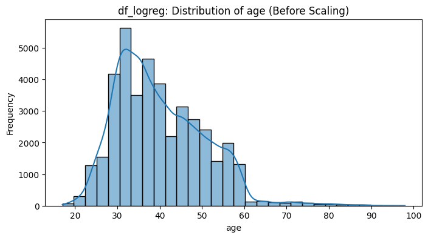

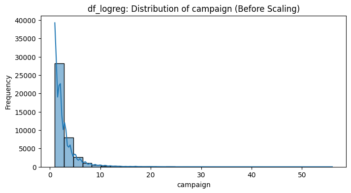

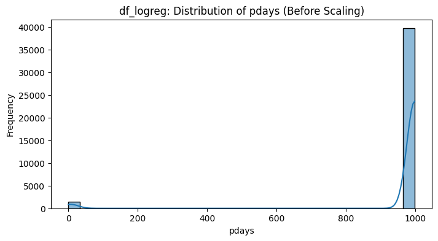

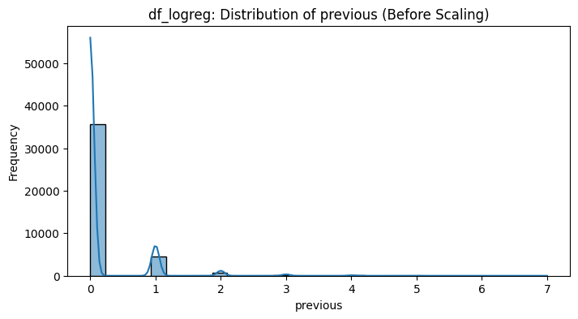

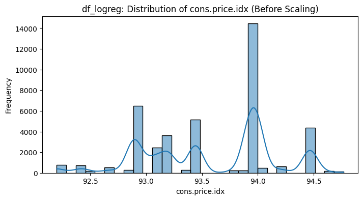

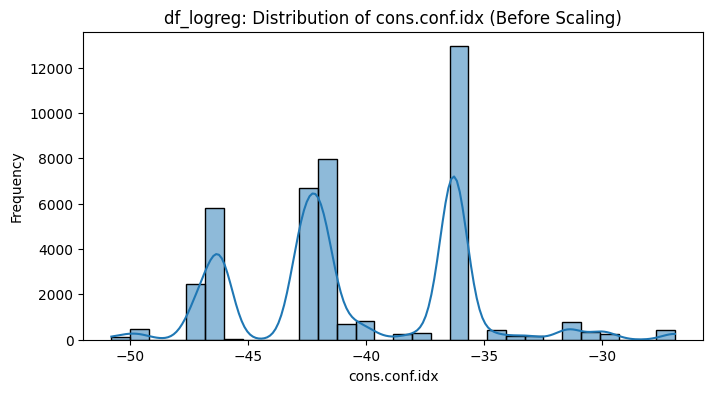

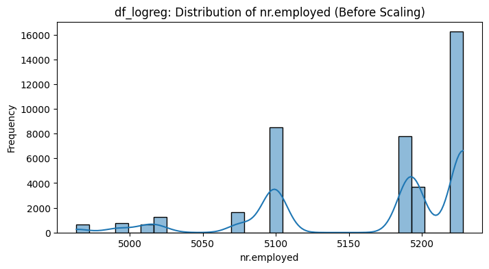

```python
# Print numerical columns before scaling
print("df_logreg: Numerical columns before scaling:")
print(df_logreg[df_logreg_numerical_features].describe())

# Print numerical columns before scaling
print("df_logreg: Numerical columns before scaling:")
for feature in df_logreg_numerical_features:
    plt.figure(figsize=(8, 4))
    sns.histplot(df[feature], bins=30, kde=True)
    plt.title(f"df_logreg: Distribution of {feature} (Before Scaling)")
    plt.xlabel(feature)
    plt.ylabel("Frequency")
    plt.show()
```

```python
# Apply StandardScaler
scaler = StandardScaler()

# Define path to save the scaler
scaler_path = "/content/drive/My Drive/UOW/CSCI218 Group Project/dataset/scaler.pkl"

# Save the trained scaler
with open(scaler_path, "wb") as file:
    pickle.dump(scaler, file)

with open(scaler_path, "rb") as file:
    scaler = pickle.load(file)  # Load the saved StandardScaler

df_logreg[df_logreg_numerical_features] = scaler.fit_transform(df_logreg[df_logreg_numerical_features])
```

```
df_logreg: Numerical columns after scaling:
                age      campaign         pdays      previous  cons.price.idx  \
count  4.118800e+04  4.118800e+04  4.118800e+04  4.118800e+04    4.118800e+04
mean  -1.880382e-16 -7.590531e-17 -2.580781e-16  5.520386e-18   -3.315820e-14
std    1.000012e+00  1.000012e+00  1.000012e+00  1.000012e+00    1.000012e+00
min   -2.209365e+00 -5.659220e-01 -5.149443e+00 -3.494943e-01   -2.374889e+00
25%   -7.699804e-01 -5.659220e-01  1.954139e-01 -3.494943e-01   -8.649547e-01
50%   -1.942267e-01 -2.049085e-01  1.954139e-01 -3.494943e-01    2.994571e-01
75%    6.694038e-01  1.561049e-01  1.954139e-01 -3.494943e-01    7.227225e-01
max    5.563310e+00  1.928982e+01  1.954139e-01  1.379492e+01    2.058168e+00

       cons.conf.idx   nr.employed
count   4.118800e+04  4.118800e+04
mean   -1.352495e-16 -1.024860e-14
std     1.000012e+00  1.000012e+00
min    -2.224953e+00 -2.815697e+00
25%    -4.747909e-01 -9.402810e-01
50%    -2.803284e-01  3.316799e-01
75%     8.864466e-01  8.451701e-01
max     2.939106e+00  8.451701e-01
df_logreg: Numerical columns after scaling:
```

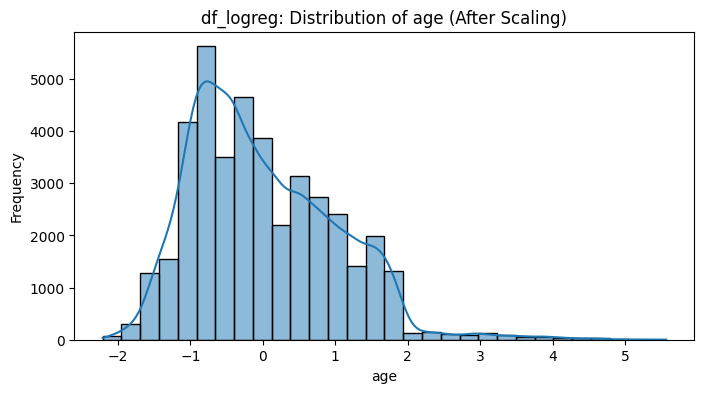

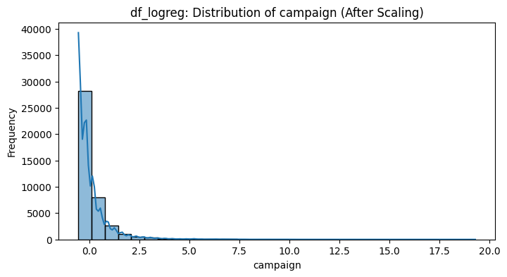

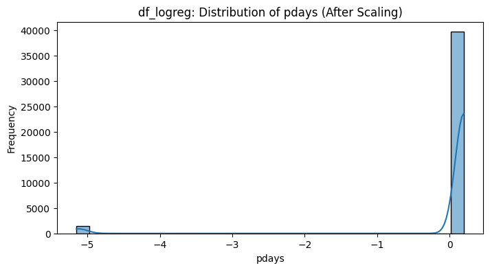

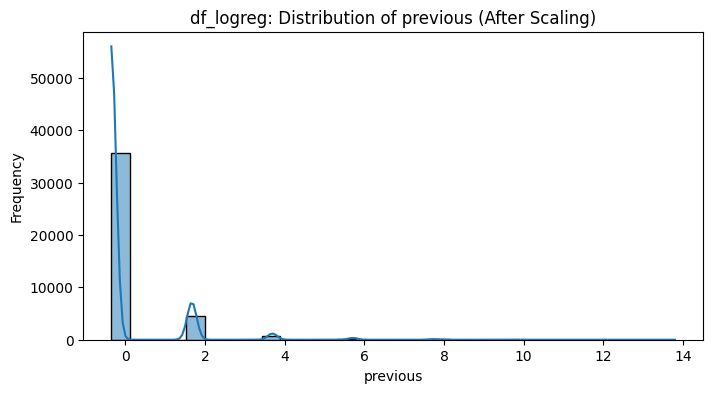

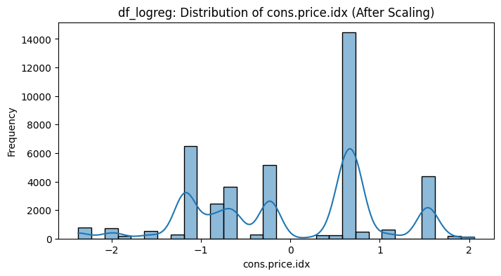

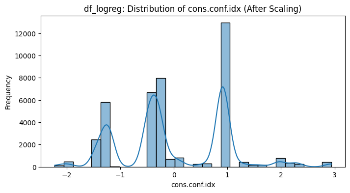

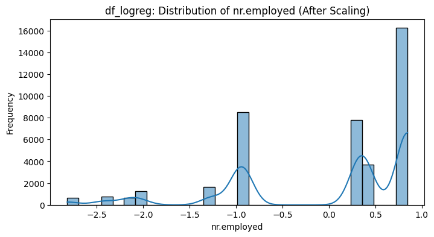

```python
# Print numerical columns after scaling
print("df_logreg: Numerical columns after scaling:")
print(df_logreg[df_logreg_numerical_features].describe())

# Print numerical columns after scaling
print("df_logreg: Numerical columns after scaling:")
for feature in df_logreg_numerical_features:
    plt.figure(figsize=(8, 4))
    sns.histplot(df_logreg[feature], bins=30, kde=True)
    plt.title(f"df_logreg: Distribution of {feature} (After Scaling)")
    plt.xlabel(feature)
    plt.ylabel("Frequency")
    plt.show()
```

```python
# Final Data Check
# Check dataset information
df_logreg.info()

# Show basic statistics
df_logreg.describe()

df_logreg.head()
```

```
<class 'pandas.core.frame.DataFrame'>
RangeIndex: 41188 entries, 0 to 41187
Data columns (total 51 columns):
 #   Column                         Non-Null Count  Dtype
---  ------                         --------------  -----
 0   age                            41188 non-null  float64
 1   campaign                       41188 non-null  float64
 2   pdays                          41188 non-null  float64
 3   previous                       41188 non-null  float64
 4   cons.price.idx                 41188 non-null  float64
 5   cons.conf.idx                  41188 non-null  float64
 6   nr.employed                    41188 non-null  float64
 7   job_blue-collar                41188 non-null  bool
 8   job_entrepreneur               41188 non-null  bool
 9   job_housemaid                  41188 non-null  bool
```

[output cut: 43 more lines]

|  | age | campaign | pdays | previous | cons.price.idx | cons.conf.idx | nr.employed | job_blue-collar | job_entrepreneur | job_housemaid | job_management | job_retired | job_self-employed | job_services | job_student | job_technician | job_unemployed | job_unknown | marital_married | marital_single | marital_unknown | education_basic.6y | education_basic.9y | education_high.school | education_illiterate | education_professional.course | education_university.degree | education_unknown | default_unknown | … |
| --- | --- | --- | --- | --- | --- | --- | --- | --- | --- | --- | --- | --- | --- | --- | --- | --- | --- | --- | --- | --- | --- | --- | --- | --- | --- | --- | --- | --- | --- | --- |
| 0 | 1.533034 | -0.565922 | 0.195414 | -0.349494 | 0.722722 | 0.886447 | 0.33168 | False | False | True | False | False | False | False | False | False | False | False | True | False | False | False | False | False | False | False | False | False | False | … |
| 1 | 1.628993 | -0.565922 | 0.195414 | -0.349494 | 0.722722 | 0.886447 | 0.33168 | False | False | False | False | False | False | True | False | False | False | False | True | False | False | False | False | True | False | False | False | False | True | … |
| 2 | -0.290186 | -0.565922 | 0.195414 | -0.349494 | 0.722722 | 0.886447 | 0.33168 | False | False | False | False | False | False | True | False | False | False | False | True | False | False | False | False | True | False | False | False | False | False | … |
| 3 | -0.002309 | -0.565922 | 0.195414 | -0.349494 | 0.722722 | 0.886447 | 0.33168 | False | False | False | False | False | False | False | False | False | False | False | True | False | False | True | False | False | False | False | False | False | False | … |
| 4 | 1.533034 | -0.565922 | 0.195414 | -0.349494 | 0.722722 | 0.886447 | 0.33168 | False | False | False | False | False | False | True | False | False | False | False | True | False | False | False | False | True | False | False | False | False | False | … |

```
df: Numerical columns before scaling:
               age      campaign         pdays      previous  emp.var.rate  \
count  41188.00000  41188.000000  41188.000000  41188.000000  41188.000000
mean      40.02406      2.567593    962.475454      0.172963      0.081886
std       10.42125      2.770014    186.910907      0.494901      1.570960
min       17.00000      1.000000      0.000000      0.000000     -3.400000
25%       32.00000      1.000000    999.000000      0.000000     -1.800000
50%       38.00000      2.000000    999.000000      0.000000      1.100000
75%       47.00000      3.000000    999.000000      0.000000      1.400000
max       98.00000     56.000000    999.000000      7.000000      1.400000

       cons.price.idx  cons.conf.idx     euribor3m   nr.employed
count    41188.000000   41188.000000  41188.000000  41188.000000
mean        93.575664     -40.502600      3.621291   5167.035911
std          0.578840       4.628198      1.734447     72.251528
min         92.201000     -50.800000      0.634000   4963.600000
25%         93.075000     -42.700000      1.344000   5099.100000
50%         93.749000     -41.800000      4.857000   5191.000000
75%         93.994000     -36.400000      4.961000   5228.100000
max         94.767000     -26.900000      5.045000   5228.100000
df: Numerical columns before scaling:
```

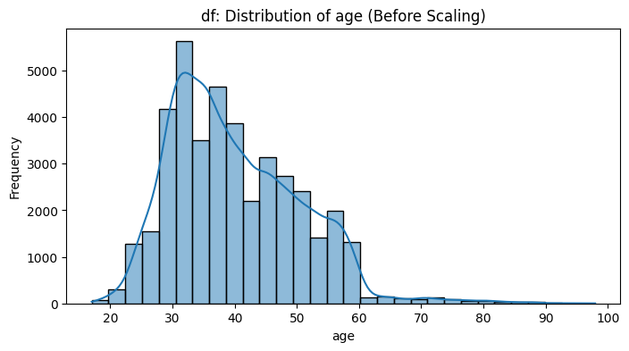

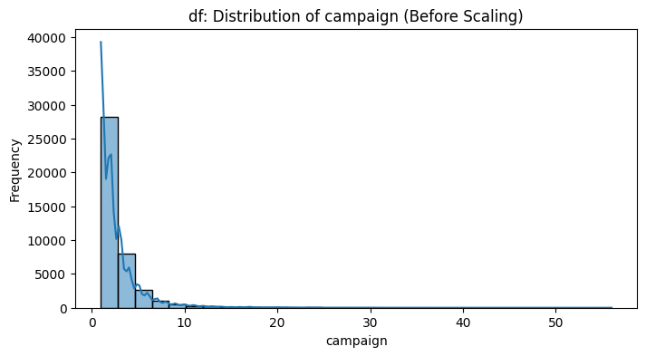

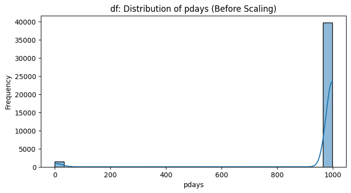

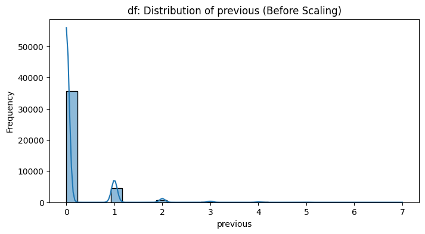

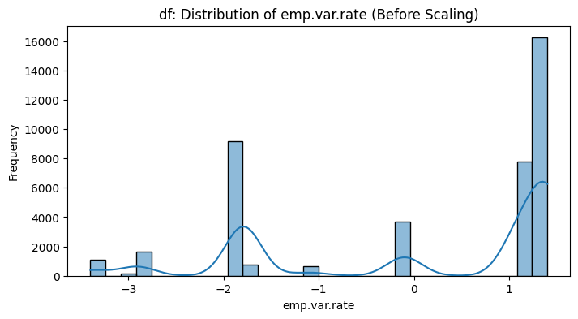

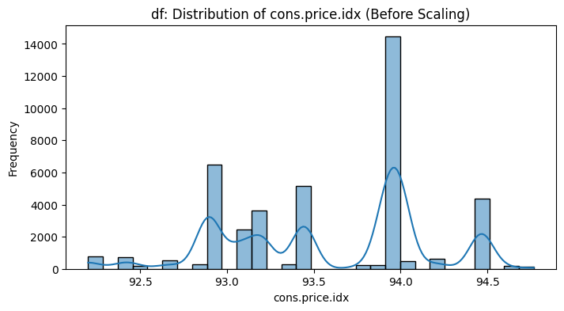

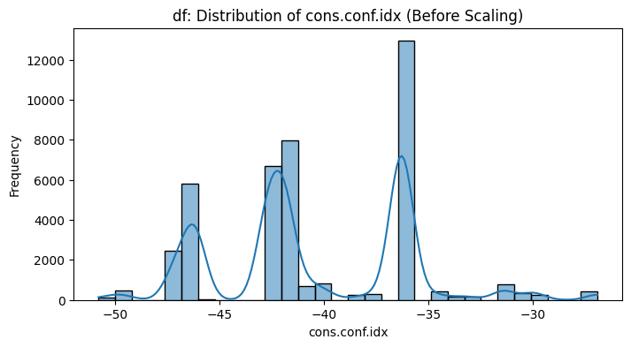

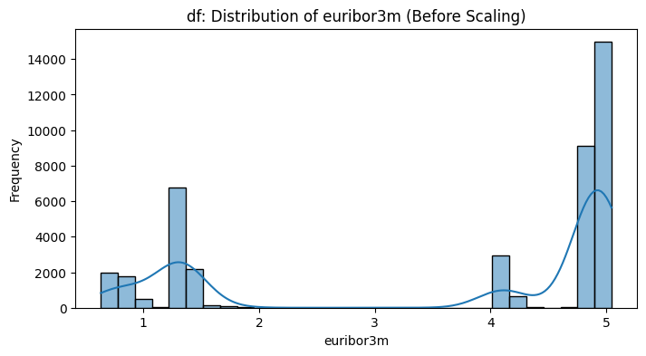

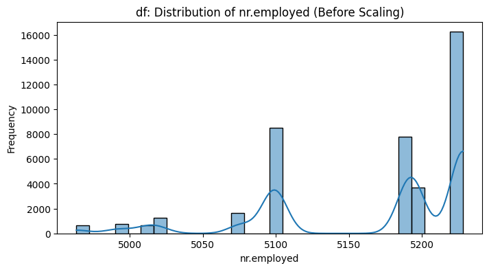

```python
# Print numerical columns before scaling
print("df: Numerical columns before scaling:")
print(df[df_numerical_features].describe())

# Print numerical columns before scaling
print("df: Numerical columns before scaling:")
for feature in df_numerical_features:
    plt.figure(figsize=(8, 4))
    sns.histplot(df[feature], bins=30, kde=True)
    plt.title(f"df: Distribution of {feature} (Before Scaling)")
    plt.xlabel(feature)
    plt.ylabel("Frequency")
    plt.show()
```

```python
# Apply StandardScaler
df[df_numerical_features] = scaler.fit_transform(df[df_numerical_features])
```

```
df: Numerical columns after scaling:
                age      campaign         pdays      previous  emp.var.rate  \
count  4.118800e+04  4.118800e+04  4.118800e+04  4.118800e+04  4.118800e+04
mean  -1.880382e-16 -7.590531e-17 -2.580781e-16  5.520386e-18  7.797546e-17
std    1.000012e+00  1.000012e+00  1.000012e+00  1.000012e+00  1.000012e+00
min   -2.209365e+00 -5.659220e-01 -5.149443e+00 -3.494943e-01 -2.216433e+00
25%   -7.699804e-01 -5.659220e-01  1.954139e-01 -3.494943e-01 -1.197935e+00
50%   -1.942267e-01 -2.049085e-01  1.954139e-01 -3.494943e-01  6.480923e-01
75%    6.694038e-01  1.561049e-01  1.954139e-01 -3.494943e-01  8.390606e-01
max    5.563310e+00  1.928982e+01  1.954139e-01  1.379492e+01  8.390606e-01

       cons.price.idx  cons.conf.idx     euribor3m   nr.employed
count    4.118800e+04   4.118800e+04  41188.000000  4.118800e+04
mean    -3.315820e-14  -1.352495e-16      0.000000 -1.024860e-14
std      1.000012e+00   1.000012e+00      1.000012  1.000012e+00
min     -2.374889e+00  -2.224953e+00     -1.722351 -2.815697e+00
25%     -8.649547e-01  -4.747909e-01     -1.312994 -9.402810e-01
50%      2.994571e-01  -2.803284e-01      0.712460  3.316799e-01
75%      7.227225e-01   8.864466e-01      0.772422  8.451701e-01
max      2.058168e+00   2.939106e+00      0.820853  8.451701e-01
df: Numerical columns after scaling:
```

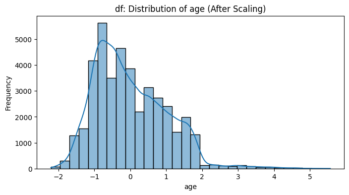

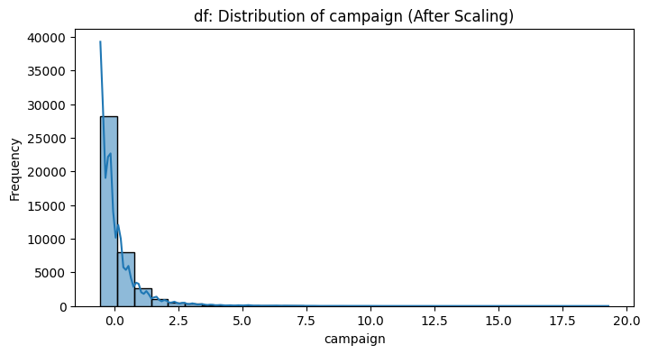

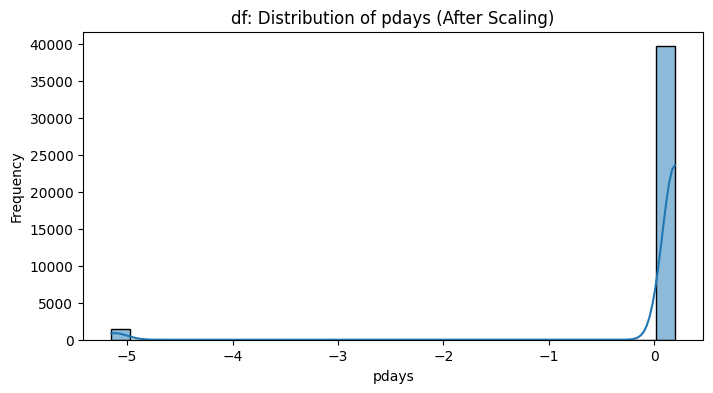

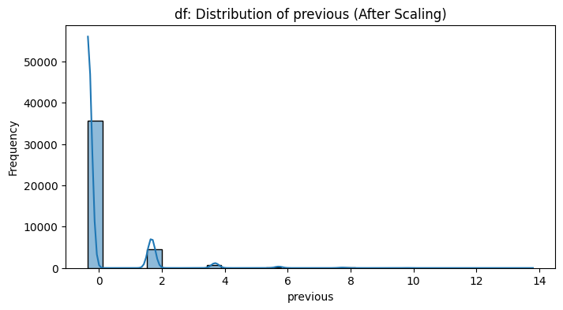

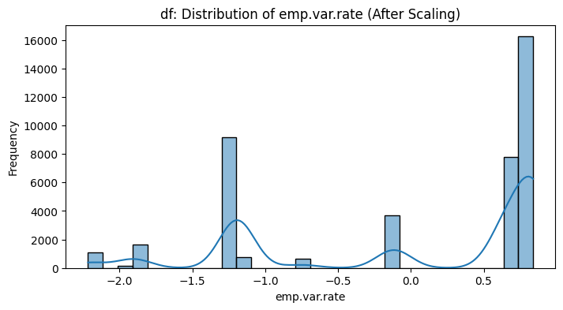

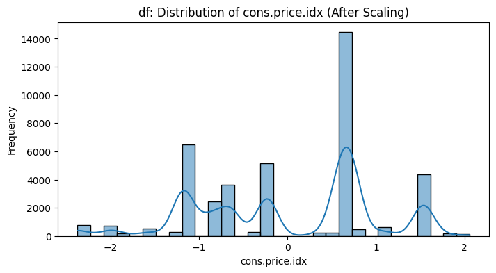

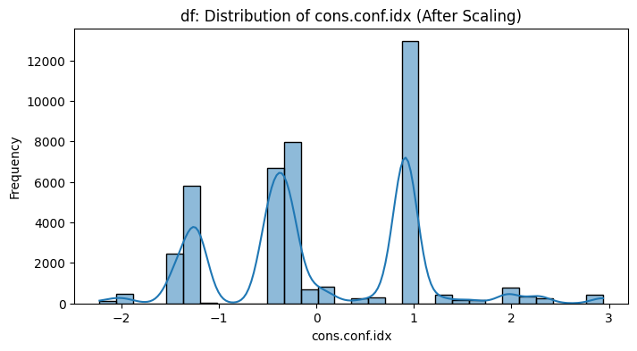

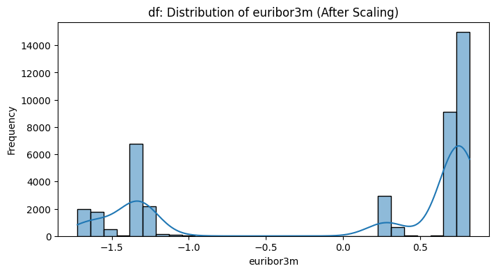

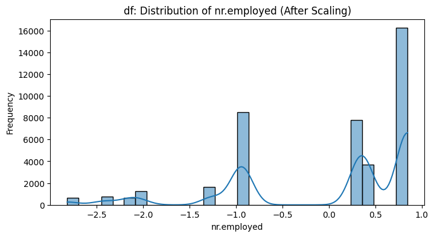

```python
# Print numerical columns after scaling
print("df: Numerical columns after scaling:")
print(df[df_numerical_features].describe())

# Print numerical columns after scaling
print("df: Numerical columns after scaling:")
for feature in df_numerical_features:
    plt.figure(figsize=(8, 4))
    sns.histplot(df[feature], bins=30, kde=True)
    plt.title(f"df: Distribution of {feature} (After Scaling)")
    plt.xlabel(feature)
    plt.ylabel("Frequency")
    plt.show()
```

```python
# Final Data Check
# Check dataset information
df.info()

# Show basic statistics
df.describe()

df.head()
```

```
<class 'pandas.core.frame.DataFrame'>
RangeIndex: 41188 entries, 0 to 41187
Data columns (total 64 columns):
 #   Column                         Non-Null Count  Dtype
---  ------                         --------------  -----
 0   age                            41188 non-null  float64
 1   campaign                       41188 non-null  float64
 2   pdays                          41188 non-null  float64
 3   previous                       41188 non-null  float64
 4   emp.var.rate                   41188 non-null  float64
 5   cons.price.idx                 41188 non-null  float64
 6   cons.conf.idx                  41188 non-null  float64
 7   euribor3m                      41188 non-null  float64
 8   nr.employed                    41188 non-null  float64
 9   job_admin.                     41188 non-null  bool
```

[output cut: 56 more lines]

|  | age | campaign | pdays | previous | emp.var.rate | cons.price.idx | cons.conf.idx | euribor3m | nr.employed | job_admin. | job_blue-collar | job_entrepreneur | job_housemaid | job_management | job_retired | job_self-employed | job_services | job_student | job_technician | job_unemployed | job_unknown | marital_divorced | marital_married | marital_single | marital_unknown | education_basic.4y | education_basic.6y | education_basic.9y | education_high.school | … |
| --- | --- | --- | --- | --- | --- | --- | --- | --- | --- | --- | --- | --- | --- | --- | --- | --- | --- | --- | --- | --- | --- | --- | --- | --- | --- | --- | --- | --- | --- | --- |
| 0 | 1.533034 | -0.565922 | 0.195414 | -0.349494 | 0.648092 | 0.722722 | 0.886447 | 0.71246 | 0.33168 | False | False | False | True | False | False | False | False | False | False | False | False | False | True | False | False | True | False | False | False | … |
| 1 | 1.628993 | -0.565922 | 0.195414 | -0.349494 | 0.648092 | 0.722722 | 0.886447 | 0.71246 | 0.33168 | False | False | False | False | False | False | False | True | False | False | False | False | False | True | False | False | False | False | False | True | … |
| 2 | -0.290186 | -0.565922 | 0.195414 | -0.349494 | 0.648092 | 0.722722 | 0.886447 | 0.71246 | 0.33168 | False | False | False | False | False | False | False | True | False | False | False | False | False | True | False | False | False | False | False | True | … |
| 3 | -0.002309 | -0.565922 | 0.195414 | -0.349494 | 0.648092 | 0.722722 | 0.886447 | 0.71246 | 0.33168 | True | False | False | False | False | False | False | False | False | False | False | False | False | True | False | False | False | True | False | False | … |
| 4 | 1.533034 | -0.565922 | 0.195414 | -0.349494 | 0.648092 | 0.722722 | 0.886447 | 0.71246 | 0.33168 | False | False | False | False | False | False | False | True | False | False | False | False | False | True | False | False | False | False | False | True | … |

## Train-Test Split

```python
# Joanne Test
logreg_X = df_logreg.drop(['y_yes'], axis=1)
logreg_y = df_logreg['y_yes']

logreg_X_train, logreg_X_test, logreg_y_train, logreg_y_test = train_test_split(logreg_X, logreg_y, test_size=0.2, random_state=42, stratify=logreg_y)
```

```python
# Print dataset shapes
print(f"X_train shape: {logreg_X_train.shape}, y_train shape: {logreg_y_train.shape}")
print(f"X_test shape: {logreg_X_test.shape}, y_test shape: {logreg_y_test.shape}")
```

```
X_train shape: (32950, 50), y_train shape: (32950,)
X_test shape: (8238, 50), y_test shape: (8238,)
```

```python
# Define features and target
X = df.drop(['y_yes','y_no'], axis=1)
y = df['y_yes']

# Split the dataset into training and testing sets
X_train, X_test, y_train, y_test = train_test_split(X, y, test_size=0.2, random_state=42, stratify=y)
```

```python
# Print dataset shapes
print(f"X_train shape: {X_train.shape}, y_train shape: {y_train.shape}")
print(f"X_test shape: {X_test.shape}, y_test shape: {y_test.shape}")
```

```
X_train shape: (32950, 62), y_train shape: (32950,)
X_test shape: (8238, 62), y_test shape: (8238,)
```

# Model Training & Fine-Tuning

```python
# To print out all model metrics in 1 function
def print_metrics(accuracy, conf_matrix, class_report):
    print(f"Accuracy: {accuracy:.4f}")
    print("Confusion Matrix:\n", conf_matrix)
    print("Classification Report:\n", class_report)
```

## Logistic Regression

```python
# Initialize and train the model
logreg = LogisticRegression(max_iter=1000, random_state=42, class_weight = 'balanced')
logreg.fit(logreg_X_train, logreg_y_train)

# Make predictions
logreg_y_train_pred = logreg.predict(logreg_X_train)
logreg_y_test_pred = logreg.predict(logreg_X_test)

# Evaluate on train set
train_accuracy = accuracy_score(logreg_y_train, logreg_y_train_pred)
train_conf_matrix = confusion_matrix(logreg_y_train, logreg_y_train_pred)
train_class_report = classification_report(logreg_y_train, logreg_y_train_pred)

# Print Train Set Results
print("\nLogistic Regression Model Performance on Train Set")
print(f"Accuracy: {train_accuracy:.4f}")
print("Confusion Matrix:\n", train_conf_matrix)
print("Classification Report:\n", train_class_report)

# Evaluate on test set
test_accuracy = accuracy_score(logreg_y_test, logreg_y_test_pred)
test_conf_matrix = confusion_matrix(logreg_y_test, logreg_y_test_pred)
test_class_report = classification_report(logreg_y_test, logreg_y_test_pred)

# Print Test Set Results
print("\nLogistic Regression Model Performance on Test Set")
print(f"Accuracy: {test_accuracy:.4f}")
print("Confusion Matrix:\n", test_conf_matrix)
print("Classification Report:\n", test_class_report)
```

```
Logistic Regression Model Performance on Train Set
Accuracy: 0.8244
Confusion Matrix:
 [[24843  4395]
 [ 1391  2321]]
Classification Report:
               precision    recall  f1-score   support

       False       0.95      0.85      0.90     29238
        True       0.35      0.63      0.45      3712

    accuracy                           0.82     32950
   macro avg       0.65      0.74      0.67     32950
weighted avg       0.88      0.82      0.84     32950


Logistic Regression Model Performance on Test Set
Accuracy: 0.8291
Confusion Matrix:
 [[6232 1078]
 [ 330  598]]
Classification Report:
               precision    recall  f1-score   support

       False       0.95      0.85      0.90      7310
        True       0.36      0.64      0.46       928

    accuracy                           0.83      8238
   macro avg       0.65      0.75      0.68      8238
weighted avg       0.88      0.83      0.85      8238
```

## Logistic Regression (Feature Importance)

❗ **If you want to try to drop columns to see any model improvement can use feature importance to drop low importance features. Else, if not using can remove this section.**

***How to read SHAP?***

**Y-Axis: Features Ranked by Importance**

**X-Axis: SHAP Value (Impact on Model Output)**

Negative SHAP value → Decreases the likelihood of predicting the positive class (y = 1).

Positive SHAP value → Increases the likelihood of predicting the positive class (y = 1). The further from zero, the stronger the impact.

**Color: Feature Value**

Red = High feature value (e.g., high nr.employed or previous count).

Blue = Low feature value (e.g., low pdays).

```python
# import shap

# logreg_X_train_float = logreg_X_train.astype(float)

# explainer = shap.LinearExplainer(logreg, logreg_X_train_float)
# shap_values = explainer(logreg_X_train_float)

# shap.summary_plot(shap_values, logreg_X_train_float, feature_names=logreg_X_train_float.columns)
```

> Jo: Permutation Importance is scale-independent, so it is accurate to compare feature importance between one-hot encoded categorical variables and standardized continuous variables. This is because Permutation Importance measures importance by shuffling feature values and observing the impact on model performance, rather than relying on raw coefficient magnitudes.

```python
# from sklearn.inspection import permutation_importance

# # Permutation Importance
# perm_importance = permutation_importance(logreg, logreg_X_test, logreg_y_test, n_repeats=30, random_state=42, n_jobs=-1)
# perm_importance_df = pd.DataFrame({
#     'Feature': logreg_X.columns,
#     'Importance Mean': perm_importance.importances_mean,
#     'Importance Std': perm_importance.importances_std
# })
# print("\nPermutation Importance:")
# print(perm_importance_df.sort_values(by='Importance Mean', ascending=False))
```

> Jo: May not be accurate to directly compare the magnitudes of coefficients and odds ratios between one-hot encoded categorical features and standardized continuous variables because they are on different scales.

```python
# # Coefficients and Odds Ratios
# coefficients = logreg.coef_[0]
# odds_ratios = np.exp(coefficients)

# # Display feature importance using coefficients and odds ratios
# feature_importance = pd.DataFrame({
#     'Feature': logreg_X.columns,
#     'Coefficient': coefficients,
#     'Odds Ratio': odds_ratios
# })

# # Sort by absolute coefficient magnitude
# feature_importance_sorted = feature_importance.reindex(feature_importance['Coefficient'].abs().sort_values(ascending=False).index)

# print("\nFeature Importance (Sorted by Magnitude of Coefficient):")
# print(feature_importance_sorted)
```

## Logistic Regression (Fine Tuning)

> Jo: l1_ratio does not apply to 'penalty': ['l1', 'l2']

```python
# Define the parameter grid for fine-tuning
param_grid = [
    {'C': np.logspace(-3, 3, 3), 'penalty': ['l1'], 'solver': ['liblinear']},
    {'C': np.logspace(-3, 3, 3), 'penalty': ['l2'], 'solver': ['liblinear','lbfgs']},
    {'C': np.logspace(-3, 3, 3), 'penalty': ['elasticnet'], 'solver': ['saga'], 'l1_ratio': [0.3, 0.5, 0.7]}
]

# GridSearchCV using recall for scoring
grid_search = GridSearchCV(
    LogisticRegression(max_iter=1000, random_state=42, class_weight='balanced'),
    param_grid, cv=3, scoring=make_scorer(recall_score), n_jobs=-1, verbose=2
)

grid_search.fit(logreg_X_train, logreg_y_train)

# Get the best model and parameters
best_logreg = grid_search.best_estimator_
print("\nBest Logistic Regression Model Performance")
print(f"Best Parameters: {grid_search.best_params_}")

# Make predictions using the fine-tuned model
best_logreg_y_train_pred = best_logreg.predict(logreg_X_train)
best_logreg_y_test_pred = best_logreg.predict(logreg_X_test)

# Evaluate on train set
train_accuracy = accuracy_score(logreg_y_train, best_logreg_y_train_pred)
train_conf_matrix = confusion_matrix(logreg_y_train, best_logreg_y_train_pred)
train_class_report = classification_report(logreg_y_train, best_logreg_y_train_pred)

# Print Train Set Results
print("\nFine-Tuned Logistic Regression Model Performance on Train Set")
print(f"Accuracy: {train_accuracy:.4f}")
print("Confusion Matrix:\n", train_conf_matrix)
print("Classification Report:\n", train_class_report)

# Evaluate on test set
test_accuracy = accuracy_score(logreg_y_test, best_logreg_y_test_pred)
test_conf_matrix = confusion_matrix(logreg_y_test, best_logreg_y_test_pred)
test_class_report = classification_report(logreg_y_test, best_logreg_y_test_pred)

# Print Test Set Results
print("\nFine-Tuned Logistic Regression Model Performance on Test Set")
print(f"Accuracy: {test_accuracy:.4f}")
print("Confusion Matrix:\n", test_conf_matrix)
print("Classification Report:\n", test_class_report)
```

```
Fitting 3 folds for each of 18 candidates, totalling 54 fits

Best Logistic Regression Model Performance
Best Parameters: {'C': 0.001, 'penalty': 'l1', 'solver': 'liblinear'}

Fine-Tuned Logistic Regression Model Performance on Train Set
Accuracy: 0.7173
Confusion Matrix:
 [[21011  8227]
 [ 1089  2623]]
Classification Report:
               precision    recall  f1-score   support

       False       0.95      0.72      0.82     29238
        True       0.24      0.71      0.36      3712

    accuracy                           0.72     32950
   macro avg       0.60      0.71      0.59     32950
weighted avg       0.87      0.72      0.77     32950


Fine-Tuned Logistic Regression Model Performance on Test Set
Accuracy: 0.7270
Confusion Matrix:
 [[5308 2002]
 [ 247  681]]
Classification Report:
               precision    recall  f1-score   support

       False       0.96      0.73      0.83      7310
        True       0.25      0.73      0.38       928

    accuracy                           0.73      8238
   macro avg       0.60      0.73      0.60      8238
weighted avg       0.88      0.73      0.77      8238
```

💡 **Recall for testset after fine-tuning = 73% which means the Logistic Regression model only missed out 27% of client who subscribed the bank term deposit.**

## Data split

```python
# Define features and target
rf_X = df.drop(['y_yes','y_no'], axis=1)
rf_y = df['y_yes']

# Split the dataset into training and testing sets
rf_X_train, rf_X_test, rf_y_train, rf_y_test = train_test_split(rf_X, rf_y, test_size=0.2, random_state=42, stratify=rf_y)
```

```python
from sklearn.ensemble import RandomForestClassifier
from sklearn.metrics import accuracy_score, classification_report, confusion_matrix
from sklearn.model_selection import GridSearchCV
```

```python
# Initialize Random Forest model
rf_model = RandomForestClassifier(n_estimators=100, random_state=42)  # 100 trees

# Train the model
rf_model.fit(rf_X_train, rf_y_train)
```

```
RandomForestClassifier(random_state=42)
```

```python
# Predict on test data
rf_y_pred = rf_model.predict(rf_X_test)
rf_y_pred_train = rf_model.predict(rf_X_train)
```

```python
# Evaluation of model on train data
rf_accuracy_train = accuracy_score(rf_y_train, rf_y_pred_train)
rf_cm_train = confusion_matrix(rf_y_train, rf_y_pred_train)
rf_report_train = classification_report(rf_y_train, rf_y_pred_train)

print(f"Accuracy of Random Forest train data: {rf_accuracy_train}")
print(f"Confusion Matrix of Random Forest train data: \n{rf_cm_train}")
print(f"Classification report of Random Forest train data: \n{rf_report_train}")
```

```
Accuracy of Random Forest train data: 0.9953262518968133
Confusion Matrix of Random Forest train data:
[[29218    20]
 [  134  3578]]
Classification report of Random Forest train data:
              precision    recall  f1-score   support

       False       1.00      1.00      1.00     29238
        True       0.99      0.96      0.98      3712

    accuracy                           1.00     32950
   macro avg       0.99      0.98      0.99     32950
weighted avg       1.00      1.00      1.00     32950
```

```python
# Evaluation of model on test data
rf_accuracy = accuracy_score(rf_y_test, rf_y_pred)
rf_cm = confusion_matrix(rf_y_test, rf_y_pred)
rf_report = classification_report(rf_y_test, rf_y_pred)

print(f"Accuracy of Random Forest test data: {rf_accuracy}")
print(f"Confusion Matrix of Random Forest test data: \n{rf_cm}")
print(f"Classification report of Random Forest test data: \n{rf_report}")
```

```
Accuracy of Random Forest test data: 0.8973051711580481
Confusion Matrix of Random Forest test data:
[[7111  199]
 [ 647  281]]
Classification report of Random Forest test data:
              precision    recall  f1-score   support

       False       0.92      0.97      0.94      7310
        True       0.59      0.30      0.40       928

    accuracy                           0.90      8238
   macro avg       0.75      0.64      0.67      8238
weighted avg       0.88      0.90      0.88      8238
```

## Random Forest (Fine Tuning)

We need to use class_weight balanced in this case because of the imbalance dataset.

```python
balanced_rf_model = RandomForestClassifier(n_estimators=100, random_state=42, class_weight="balanced")
```

```python
param_grid = {
    'n_estimators': [100, 300, 500],
    'max_depth': [10, 20, 30, None],
    'min_samples_split': [2, 5, 10],
    'min_samples_leaf': [1, 2, 4],
    'class_weight': ['balanced']
}

# searching for the best recall
grid_search = GridSearchCV(RandomForestClassifier(random_state=42), param_grid, cv=5, scoring='recall')
grid_search.fit(rf_X_train, rf_y_train)

# Best model
best_rf = grid_search.best_estimator_
print("Best parameters:", grid_search.best_params_)
```

```
Best parameters: {'class_weight': 'balanced', 'max_depth': 10, 'min_samples_leaf': 4, 'min_samples_split': 2, 'n_estimators': 100}
```

```python
# Predict on train and test set
best_rf_y_train_pred_train = best_rf.predict(rf_X_train)
best_rf_y_test_pred_test = best_rf.predict(rf_X_test)
```

```python
# Evaluation of model on train data
rf_accuracy_tuned_train = accuracy_score(rf_y_train, best_rf_y_train_pred_train)
rf_cm_tuned_train = confusion_matrix(rf_y_train, best_rf_y_train_pred_train)
rf_report_tuned_train = classification_report(rf_y_train, best_rf_y_train_pred_train)

print(f"Accuracy of Random Forest tuned data: {rf_accuracy_tuned_train}")
print(f"Confusion Matrix of Random Forest tuned data: \n{rf_cm_tuned_train}")
print(f"Classification report of Random Forest tuned data: \n{rf_report_tuned_train}")
```

```
Accuracy of Random Forest tuned data: 0.855174506828528
Confusion Matrix of Random Forest tuned data:
[[25854  3384]
 [ 1388  2324]]
Classification report of Random Forest tuned data:
              precision    recall  f1-score   support

       False       0.95      0.88      0.92     29238
        True       0.41      0.63      0.49      3712

    accuracy                           0.86     32950
   macro avg       0.68      0.76      0.70     32950
weighted avg       0.89      0.86      0.87     32950
```

```python
# Evaluation of model on test data
rf_accuracy_tuned_test = accuracy_score(rf_y_test, best_rf_y_test_pred_test)
rf_cm_tuned_test = confusion_matrix(rf_y_test, best_rf_y_test_pred_test)
rf_report_tuned_test = classification_report(rf_y_test, best_rf_y_test_pred_test)

print(f"Accuracy of Random Forest tuned data: {rf_accuracy_tuned_test}")
print(f"Confusion Matrix of Random Forest tuned data: \n{rf_cm_tuned_test}")
print(f"Classification report of Random Forest tuned data: \n{rf_report_tuned_test}")
```

```
Accuracy of Random Forest tuned data: 0.8578538480213644
Confusion Matrix of Random Forest tuned data:
[[6479  831]
 [ 340  588]]
Classification report of Random Forest tuned data:
              precision    recall  f1-score   support

       False       0.95      0.89      0.92      7310
        True       0.41      0.63      0.50       928

    accuracy                           0.86      8238
   macro avg       0.68      0.76      0.71      8238
weighted avg       0.89      0.86      0.87      8238
```

## XGBoost

```python
from xgboost import XGBClassifier

# Initialise XGBoost Classifier and train the model
xgb = XGBClassifier(random_state=42)
xgb.fit(X_train, y_train)

# Make predictions
xgb_y_train_pred = xgb.predict(X_train)
xgb_y_test_pred = xgb.predict(X_test)

# Evaluate on train set
xgb_train_accuracy = accuracy_score(y_train, xgb_y_train_pred)
xgb_train_conf_matrix = confusion_matrix(y_train, xgb_y_train_pred)
xgb_train_class_report = classification_report(y_train, xgb_y_train_pred)

# Print Train Set Results
print("\nXGBoost Classifier Model Performance on Train Set")
print_metrics(xgb_train_accuracy, xgb_train_conf_matrix,xgb_train_class_report)

# Evaluate on test set
xgb_test_accuracy = accuracy_score(y_test, xgb_y_test_pred)
xgb_test_conf_matrix = confusion_matrix(y_test, xgb_y_test_pred)
xgb_test_class_report = classification_report(y_test, xgb_y_test_pred)

# Print Test Set Results
print("\nXGBoost Classifier Model Performance on Test Set")
print_metrics(xgb_test_accuracy, xgb_test_conf_matrix, xgb_test_class_report)
```

```
XGBoost Classifier Model Performance on Train Set
Accuracy: 0.9299
Confusion Matrix:
 [[29039   199]
 [ 2112  1600]]
Classification Report:
               precision    recall  f1-score   support

       False       0.93      0.99      0.96     29238
        True       0.89      0.43      0.58      3712

    accuracy                           0.93     32950
   macro avg       0.91      0.71      0.77     32950
weighted avg       0.93      0.93      0.92     32950


XGBoost Classifier Model Performance on Test Set
Accuracy: 0.9020
Confusion Matrix:
 [[7153  157]
 [ 650  278]]
Classification Report:
               precision    recall  f1-score   support

       False       0.92      0.98      0.95      7310
        True       0.64      0.30      0.41       928

    accuracy                           0.90      8238
   macro avg       0.78      0.64      0.68      8238
weighted avg       0.89      0.90      0.89      8238
```

## XGBoost (Fine Tuning)

```python
# Will be using RandomSearchCV instead due to high cost of running GridSearchCV
from sklearn.model_selection import RandomizedSearchCV

# Define the parameter grid for fine-tuning
xgb_param_grid = {
    'n_estimators': [100, 300, 500, 1000],
    'max_depth': [3, 6, 9, 12],
    'learning_rate': [0.05, 0.1, 0.3, 1],
    'gamma': [0, 0.2, 0.4, 0.6, 0.8, 1],
    'lambda': [1, 5, 10],
    'alpha': [1, 5, 10],
    'subsample': [0.7, 0.8, 0.9, 1],
    'min_child_weight': [1, 5, 10],
    'scale_pos_weight': [(len(y_train[y_train == 0]) / len(y_train[y_train == 1]))]
}

# RandomSearchCV to find best parameters
xgb_random_search = RandomizedSearchCV(XGBClassifier(random_state=42), xgb_param_grid, cv=5,
                                       n_jobs=6, scoring=make_scorer(recall_score), verbose=2)

xgb_random_search.fit(X_train, y_train)

# Get the best model and predictions
xgb_rs_params = xgb_random_search.best_params_
xgb_rs = xgb_random_search.best_estimator_

print("\nBest XGBoost Classifier Model Performance")
print(f"Best Parameters: {xgb_rs_params}")

# Make predictions
best_xgb_y_train_pred = xgb_rs.predict(X_train)
best_xgb_y_test_pred = xgb_rs.predict(X_test)

# Evaluate on train set
best_xgb_train_accuracy = accuracy_score(y_train, best_xgb_y_train_pred)
best_xgb_train_conf_matrix = confusion_matrix(y_train, best_xgb_y_train_pred)
best_xgb_train_class_report = classification_report(y_train, best_xgb_y_train_pred)

# Print Train Set Results
print("\nFine-Tuned XGBoost Classifier Model Performance on Train Set")
print_metrics(best_xgb_train_accuracy, best_xgb_train_conf_matrix, best_xgb_train_class_report)

# Evaluate on test set
best_xgb_test_accuracy = accuracy_score(y_test, best_xgb_y_test_pred)
best_xgb_test_conf_matrix = confusion_matrix(y_test, best_xgb_y_test_pred)
best_xgb_test_class_report = classification_report(y_test, best_xgb_y_test_pred)

# Print Test Set Results
print("\nFine-Tuned XGBoost Classifier Model Performance on Test Set")
print_metrics(best_xgb_test_accuracy, best_xgb_test_conf_matrix, best_xgb_test_class_report)
```

```
Fitting 5 folds for each of 10 candidates, totalling 50 fits

Best XGBoost Classifier Model Performance
Best Parameters: {'subsample': 0.7, 'scale_pos_weight': 7.876616379310345, 'n_estimators': 1000, 'min_child_weight': 5, 'max_depth': 3, 'learning_rate': 0.1, 'lambda': 5, 'gamma': 0, 'alpha': 10}

Fine-Tuned XGBoost Classifier Model Performance on Train Set
Accuracy: 0.8378
Confusion Matrix:
 [[24981  4257]
 [ 1086  2626]]
Classification Report:
               precision    recall  f1-score   support

       False       0.96      0.85      0.90     29238
        True       0.38      0.71      0.50      3712

    accuracy                           0.84     32950
   macro avg       0.67      0.78      0.70     32950
weighted avg       0.89      0.84      0.86     32950


Fine-Tuned XGBoost Classifier Model Performance on Test Set
Accuracy: 0.8297
Confusion Matrix:
 [[6225 1085]
 [ 318  610]]
Classification Report:
               precision    recall  f1-score   support

       False       0.95      0.85      0.90      7310
        True       0.36      0.66      0.47       928

    accuracy                           0.83      8238
   macro avg       0.66      0.75      0.68      8238
weighted avg       0.88      0.83      0.85      8238
```

# Performance Evaluation

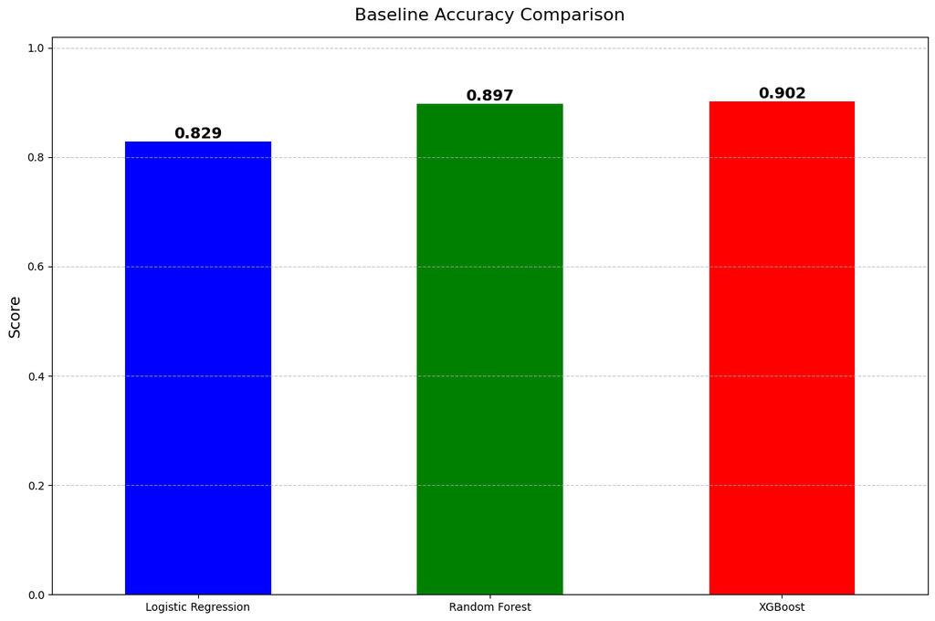

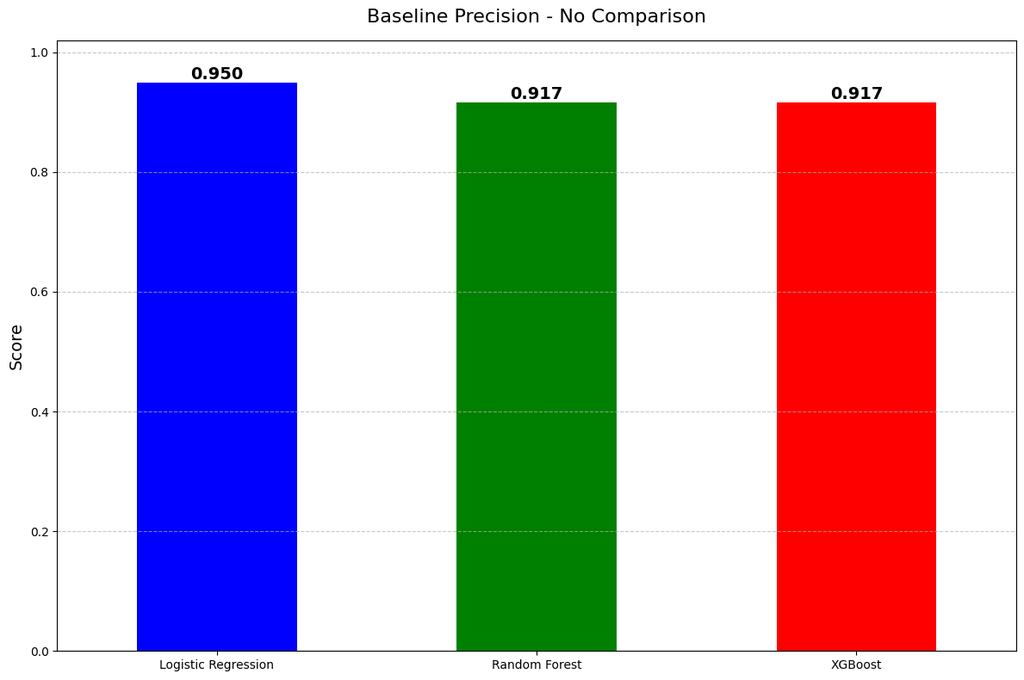

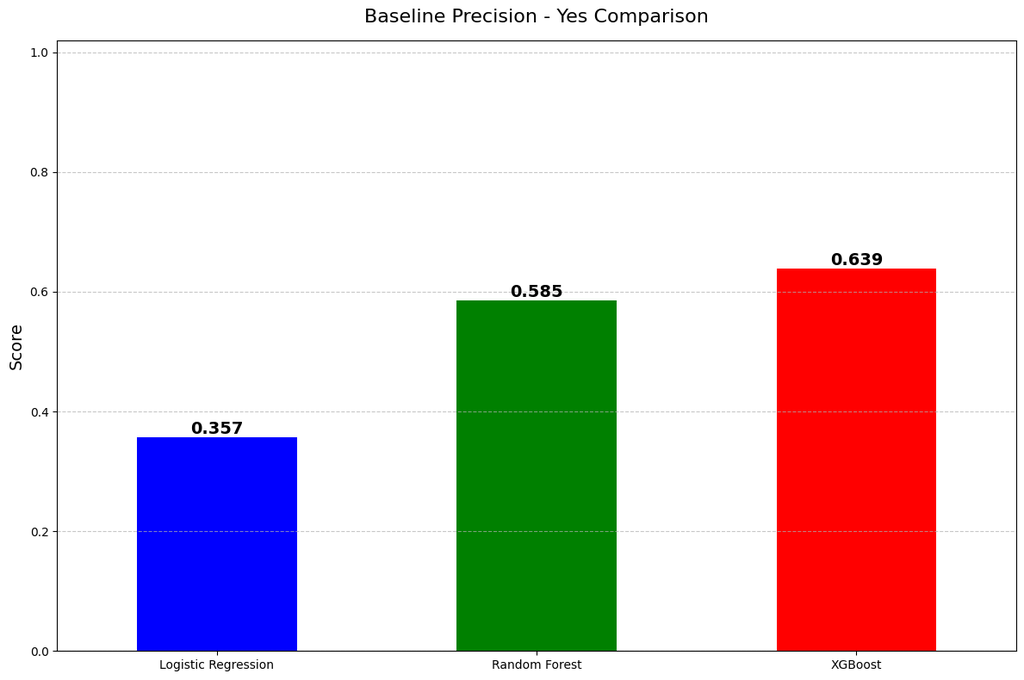

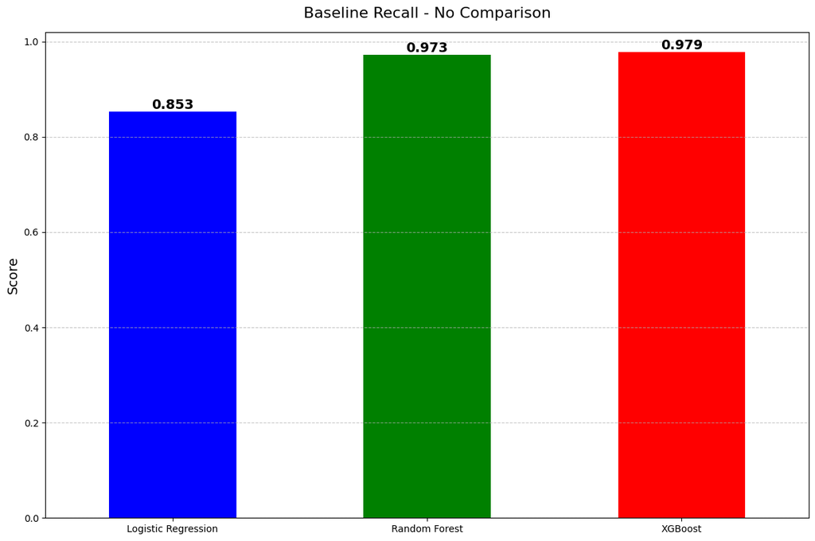

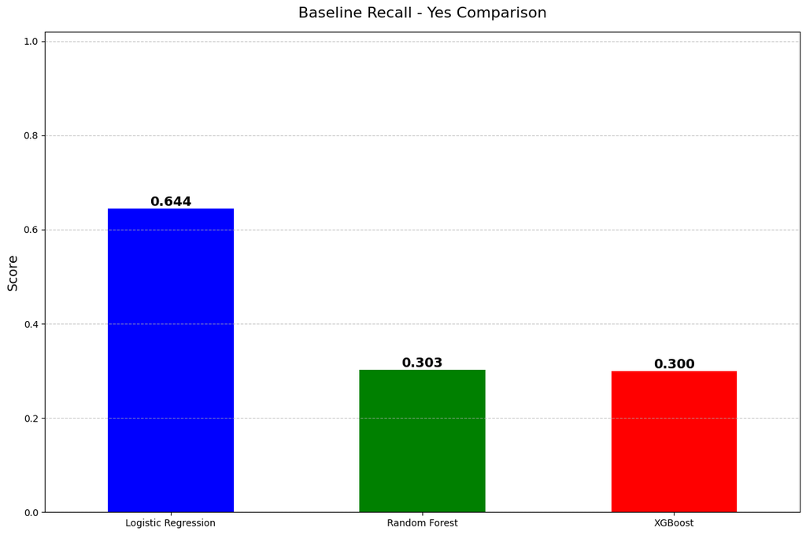

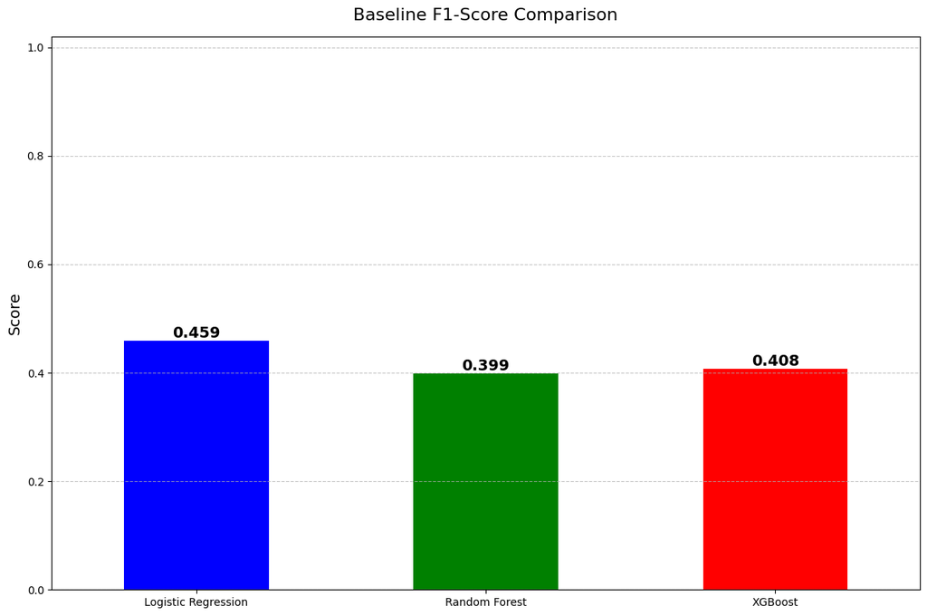

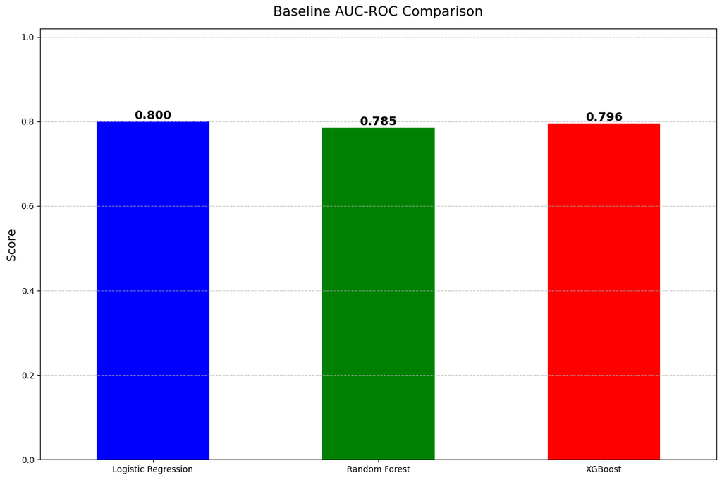

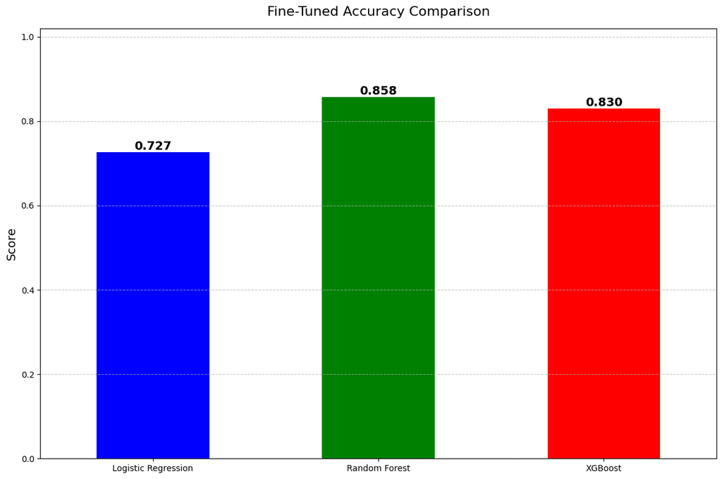

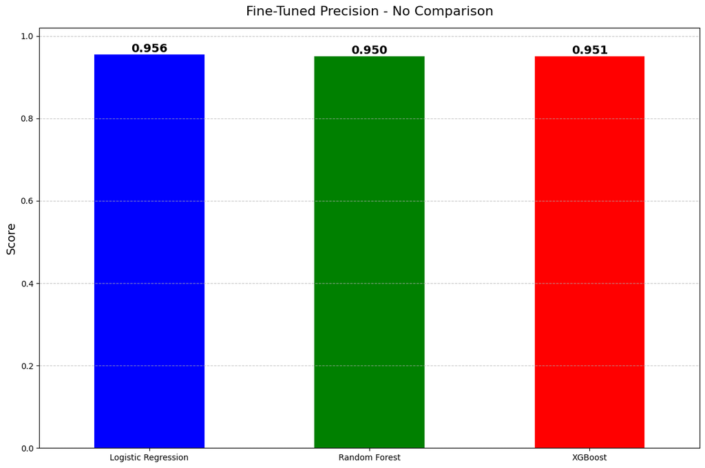

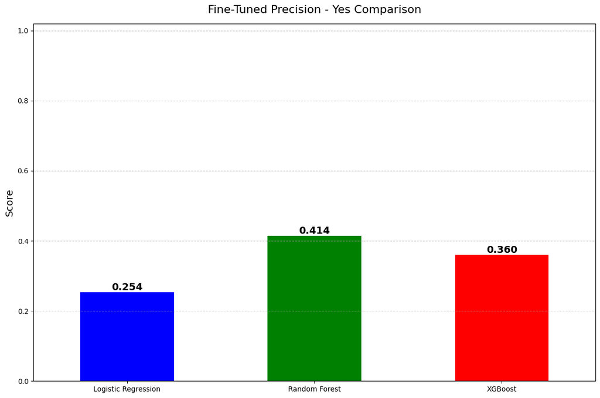

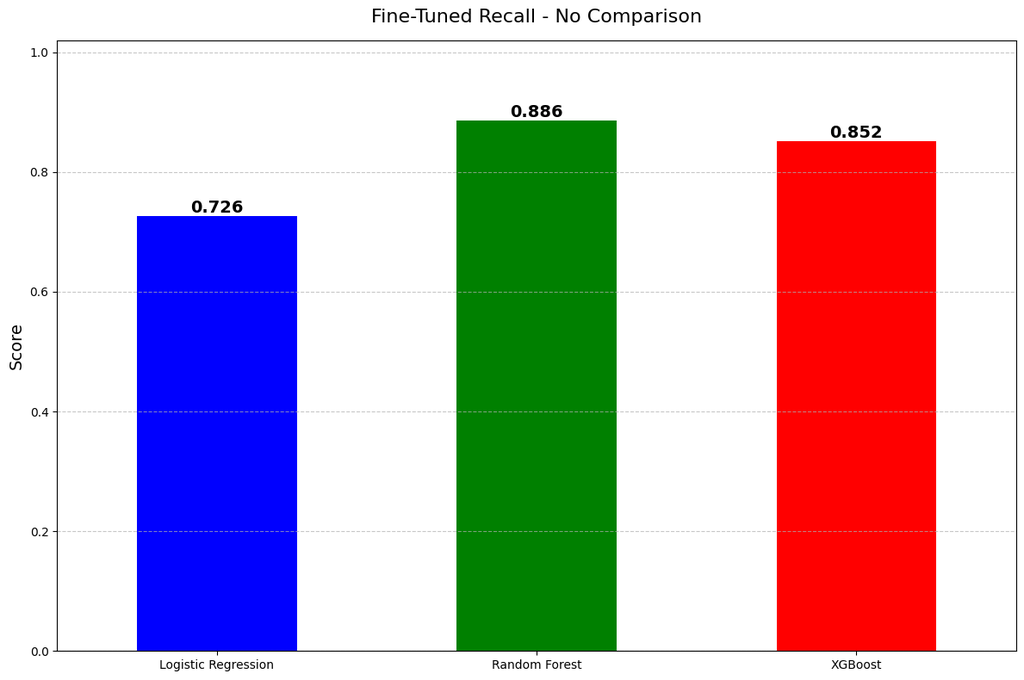

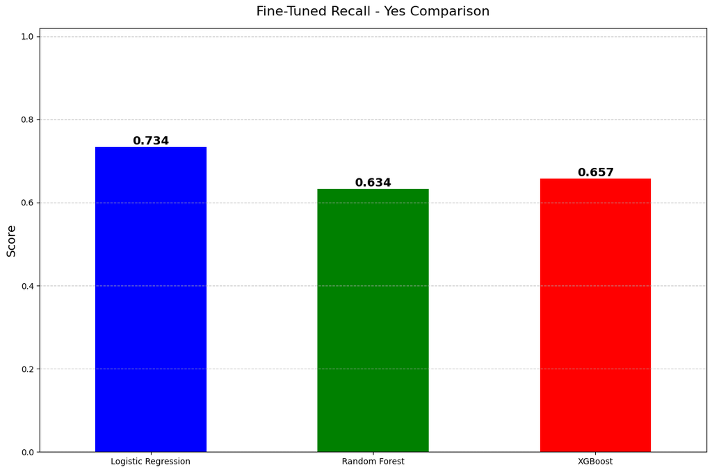

[2 more figures not shown]

```python
import matplotlib.pyplot as plt
import pandas as pd
from sklearn.metrics import (
    accuracy_score, precision_score, recall_score,
    f1_score, roc_auc_score, classification_report
)

# Define function to extract classification metrics
def get_classification_metrics(y_true, y_pred, model, proba_pred=None):
    report = classification_report(y_true, y_pred, output_dict=True)

    # Get Precision & Recall separately for Yes & No
    precision_no = report["False"]["precision"]
    precision_yes = report["True"]["precision"]
    recall_no = report["False"]["recall"]
    recall_yes = report["True"]["recall"]

    metrics = {
        "Accuracy": accuracy_score(y_true, y_pred),
        "Precision - No": precision_no,
        "Precision - Yes": precision_yes,
        "Recall - No": recall_no,
        "Recall - Yes": recall_yes,
        "F1-Score": f1_score(y_true, y_pred),
        "AUC-ROC": roc_auc_score(y_true, proba_pred[:, 1]) if proba_pred is not None else None
    }
    return metrics

# Store results for baseline models
baseline_results = {
    "Logistic Regression": get_classification_metrics(logreg_y_test, logreg_y_test_pred, logreg, logreg.predict_proba(logreg_X_test)),
    "Random Forest": get_classification_metrics(rf_y_test, rf_y_pred, rf_model, rf_model.predict_proba(rf_X_test)),
    "XGBoost": get_classification_metrics(y_test, xgb_y_test_pred, xgb, xgb.predict_proba(X_test))
}

# Store results for fine-tuned models
tuned_results = {
    "Logistic Regression": get_classification_metrics(logreg_y_test, best_logreg_y_test_pred, best_logreg, best_logreg.predict_proba(logreg_X_test)),
    "Random Forest": get_classification_metrics(rf_y_test, best_rf_y_test_pred_test, best_rf, best_rf.predict_proba(rf_X_test)),
    "XGBoost": get_classification_metrics(y_test, best_xgb_y_test_pred, xgb_rs, xgb_rs.predict_proba(X_test))
}

# Convert to DataFrames for visualization
df_baseline = pd.DataFrame(baseline_results)
df_tuned = pd.DataFrame(tuned_results)

# Function to plot each metric separately in 1x1 layout
def plot_metrics(df, title_prefix):
    metrics_to_plot = ["Accuracy", "Precision - No", "Precision - Yes", "Recall - No", "Recall - Yes", "F1-Score", "AUC-ROC"]

    for metric in metrics_to_plot:
        plt.figure(figsize=(12, 8))  # Large full-size figure for each plot
        ax = plt.gca()  # Get current axis
        bars = df.loc[metric].plot(kind="bar", ax=ax, color=["blue", "green", "red"])

        # Set x-axis labels to show model names only
        ax.set_xticklabels(df.columns, rotation=0)

        # Add numbers on top of bars
        for bar in bars.patches:
            height = bar.get_height()
            ax.text(
                bar.get_x() + bar.get_width() / 2,  # X-coordinate (center of the bar)
                height,  # Position ABOVE the bar
                f"{height:.3f}",  # Format to 3 decimal places
                ha="center", va="bottom", fontsize=14, fontweight="bold", color="black"
            )

        # Set titles and labels
        ax.set_title(f"{title_prefix} {metric} Comparison", fontsize=16, pad=15)  # Better spacing
        ax.set_ylabel("Score", fontsize=14)
        ax.set_ylim(0, 1.02)  # Ensure full-scale view
        ax.grid(axis="y", linestyle="--", alpha=0.7)

        plt.tight_layout()
        plt.show()  # Show one plot at a time

# Plot Baseline and Fine-Tuned Model Performance (1-by-1 graphs)
plot_metrics(df_baseline, "Baseline")
plot_metrics(df_tuned, "Fine-Tuned")
```

```python
print("Baseline Models Metrics\n")
print(df_baseline)
```

```
Baseline Models Metrics

                 Logistic Regression  Random Forest   XGBoost
Accuracy                    0.829085       0.897305  0.902039
Precision - No              0.949710       0.916602  0.916699
Precision - Yes             0.356802       0.585417  0.639080
Recall - No                 0.852531       0.972777  0.978523
Recall - Yes                0.644397       0.302802  0.299569
F1-Score                    0.459293       0.399148  0.407924
AUC-ROC                     0.799931       0.785114  0.796059
```

```python
print("Finetuned Models Metrics\n")
print(df_tuned)
```

```
Finetuned Models Metrics

                 Logistic Regression  Random Forest   XGBoost
Accuracy                    0.726997       0.857854  0.829692
Precision - No              0.955536       0.950139  0.951398
Precision - Yes             0.253820       0.414376  0.359882
Recall - No                 0.726129       0.886320  0.851573
Recall - Yes                0.733836       0.633621  0.657328
F1-Score                    0.377181       0.501065  0.465116
AUC-ROC                     0.788311       0.814525  0.805128
```

## Save Best Model as `.pkl`

```python
# Define paths to save the models
logreg_path = "/content/drive/My Drive/UOW/CSCI218 Group Project/dataset/bank-additional/bank-additional/logistic_regression_model.pkl"
rf_path = "/content/drive/My Drive/UOW/CSCI218 Group Project/dataset/bank-additional/bank-additional/random_forest_model.pkl"
xgb_path = "/content/drive/My Drive/UOW/CSCI218 Group Project/dataset/bank-additional/bank-additional/xgboost_model.pkl"

# Save models using joblib
joblib.dump(best_logreg, logreg_path)
joblib.dump(best_rf, rf_path)
joblib.dump(xgb_rs, xgb_path)

print("All models saved successfully!")
```

```
All models saved successfully!
```

## Load and Test Best Model with Manual Input

```python
# Define paths
file_path_manual_input = "/content/drive/My Drive/UOW/CSCI218 Group Project/dataset/bank-additional/bank-additional/3_manual_input.xlsx"

# Load the XGBoost model
xgb_model = joblib.load(xgb_path)

# Load the Random Forest model
rf_model = joblib.load(rf_path)

# Load the Logistic Regression model
lr_model = joblib.load(logreg_path)

# Load the Excel File
df_manual = pd.read_excel(file_path_manual_input)
```

```python
df_manual.head()
```

|  | age | job | marital | education | default | housing | loan | contact | month | day_of_week | duration | campaign | pdays | previous | poutcome | emp.var.rate | cons.price.idx | cons.conf.idx | euribor3m | nr.employed | y |
| --- | --- | --- | --- | --- | --- | --- | --- | --- | --- | --- | --- | --- | --- | --- | --- | --- | --- | --- | --- | --- | --- |
| 0 | 14 | unemployed | single | illiterate | unknown | no | no | telephone | may | mon | 421 | 4 | 999 | 0 | nonexistent | 1.1 | 93.994 | -36.4 | 4.857 | 5191 | ? |
| 1 | 45 | management | married | university.degree | no | yes | no | cellular | thu | wed | 185 | 1 | 2 | 1 | success | -1.8 | 93.994 | -36.4 | 1.365 | 5191 | ? |
| 2 | 75 | services | divorced | high.school | no | no | no | cellular | mar | fri | 112 | 1 | 4 | 1 | success | -0.1 | 93.994 | -36.4 | 4.191 | 5191 | ? |

```python
# Preprocessing

# Remove leading/trailing spaces from column names
df_manual.columns = df_manual.columns.str.strip()

# List of categorical columns to one-hot encode (same as training data)
categorical_cols = [
    "job", "marital", "education", "default", "housing", "loan",
    "contact", "month", "day_of_week", "poutcome"
]

# One-hot encode categorical variables
df_manual = pd.get_dummies(df_manual, columns=categorical_cols, drop_first=False)

# Expected columns from the trained model
expected_columns = [
    'age', 'campaign', 'pdays', 'previous', 'emp.var.rate', 'cons.price.idx',
    'cons.conf.idx', 'euribor3m', 'nr.employed', 'job_admin.', 'job_blue-collar',
    'job_entrepreneur', 'job_housemaid', 'job_management', 'job_retired',
    'job_self-employed', 'job_services', 'job_student', 'job_technician',
    'job_unemployed', 'job_unknown', 'marital_divorced', 'marital_married',
    'marital_single', 'marital_unknown', 'education_basic.4y',
    'education_basic.6y', 'education_basic.9y', 'education_high.school',
    'education_illiterate', 'education_professional.course',
    'education_university.degree', 'education_unknown', 'default_no',
    'default_unknown', 'default_yes', 'housing_no', 'housing_unknown',
    'housing_yes', 'loan_no', 'loan_unknown', 'loan_yes', 'contact_cellular',
    'contact_telephone', 'month_apr', 'month_aug', 'month_dec', 'month_jul',
    'month_jun', 'month_mar', 'month_may', 'month_nov', 'month_oct',
    'month_sep', 'day_of_week_fri', 'day_of_week_mon', 'day_of_week_thu',
    'day_of_week_tue', 'day_of_week_wed', 'poutcome_failure',
    'poutcome_nonexistent', 'poutcome_success'
]

# Ensure all expected columns exist, filling missing ones with 0
for col in expected_columns:
    if col not in df_manual.columns:
        df_manual[col] = False

# Keep only expected columns
df_manual = df_manual[expected_columns]

# Scaling Numeric Features with the **same saved scaler**
numerical_cols = ['age', 'campaign', 'pdays', 'previous', 'emp.var.rate',
                  'cons.price.idx', 'cons.conf.idx', 'euribor3m', 'nr.employed']

df_manual[numerical_cols] = scaler.transform(df_manual[numerical_cols])
```

```python
df_manual.head()
```

|  | age | campaign | pdays | previous | emp.var.rate | cons.price.idx | cons.conf.idx | euribor3m | nr.employed | job_admin. | job_blue-collar | job_entrepreneur | job_housemaid | job_management | job_retired | job_self-employed | job_services | job_student | job_technician | job_unemployed | job_unknown | marital_divorced | marital_married | marital_single | marital_unknown | education_basic.4y | education_basic.6y | education_basic.9y | education_high.school | … |
| --- | --- | --- | --- | --- | --- | --- | --- | --- | --- | --- | --- | --- | --- | --- | --- | --- | --- | --- | --- | --- | --- | --- | --- | --- | --- | --- | --- | --- | --- | --- |
| 0 | -2.497241 | 0.517118 | 0.195414 | -0.349494 | 0.648092 | 0.722722 | 0.886447 | 0.712460 | 0.33168 | False | False | False | False | False | False | False | False | False | False | True | False | False | False | True | False | False | False | False | False | … |
| 1 | 0.477486 | -0.565922 | -5.138743 | 1.671136 | -1.197935 | 0.722722 | 0.886447 | -1.300886 | 0.33168 | False | False | False | False | True | False | False | False | False | False | False | False | False | True | False | False | False | False | False | False | … |
| 2 | 3.356254 | -0.565922 | -5.128043 | 1.671136 | -0.115781 | 0.722722 | 0.886447 | 0.328471 | 0.33168 | False | False | False | False | False | False | False | True | False | False | False | False | True | False | False | False | False | False | False | True | … |

```python
df_rf_predictions = df_manual.copy()  # Create a copy for RF

# Random Forest Predictions
rf_predictions = rf_model.predict(df_rf_predictions)
rf_proba_predictions = rf_model.predict_proba(df_rf_predictions)

df_rf_predictions["Prediction"] = ["Yes" if pred == 1 else "No" for pred in rf_predictions]
df_rf_predictions["Probability of Yes"] = rf_proba_predictions[:, 1]
df_rf_predictions["Probability of No"] = rf_proba_predictions[:, 0]

# Print Predictions
print("\n==== Random Forest Predictions ====")
print(df_rf_predictions[["Prediction", "Probability of Yes", "Probability of No"]])
```

```
==== Random Forest Predictions ====
  Prediction  Probability of Yes  Probability of No
0         No            0.200948           0.799052
1        Yes            0.719646           0.280354
2         No            0.433572           0.566428
```

```python
df_xgb_predictions = df_manual.copy()  # Create a copy for XGB

# XGBoost Predictions
xgb_predictions = xgb_model.predict(df_xgb_predictions)
xgb_proba_predictions = xgb_model.predict_proba(df_xgb_predictions)

df_xgb_predictions["Prediction"] = ["Yes" if pred == 1 else "No" for pred in xgb_predictions]
df_xgb_predictions["Probability of Yes"] = xgb_proba_predictions[:, 1]
df_xgb_predictions["Probability of No"] = xgb_proba_predictions[:, 0]

# Print Predictions
print("\n==== XGBoost Predictions ====")
print(df_xgb_predictions[["Prediction", "Probability of Yes", "Probability of No"]])
```

```
==== XGBoost Predictions ====
  Prediction  Probability of Yes  Probability of No
0         No            0.184850           0.815150
1        Yes            0.884659           0.115341
2        Yes            0.560779           0.439221
```

```python
# Create a copy for Logistic Regression
df_lr_predictions = df_manual.copy()

# Get the feature names used during Logistic Regression training
lr_expected_features = logreg_X.columns.tolist()  # Get columns used during training

# Ensure `df_manual` has the same columns
df_lr_predictions = df_lr_predictions.reindex(columns=lr_expected_features, fill_value=False)

# Logistic Regression Predictions
lr_predictions = lr_model.predict(df_lr_predictions)
lr_proba_predictions = lr_model.predict_proba(df_lr_predictions)

df_lr_predictions["Prediction"] = ["Yes" if pred == 1 else "No" for pred in lr_predictions]
df_lr_predictions["Probability of Yes"] = lr_proba_predictions[:, 1]
df_lr_predictions["Probability of No"] = lr_proba_predictions[:, 0]

# Print Predictions
print("\n==== Logistic Regression Predictions ====")
print(df_lr_predictions[["Prediction", "Probability of Yes", "Probability of No"]])
```

```
==== Logistic Regression Predictions ====
  Prediction  Probability of Yes  Probability of No
0         No            0.335131           0.664869
1        Yes            0.671063           0.328937
2        Yes            0.670619           0.329381
```